# tree

2024-02-27

## Packages

Load required packages

```r
require(titanic)
require(dplyr)
```

```r
require(ggplot2)
require(rpart)
require(rpart.plot)
require(caret)
require(tidyr)
```

## Data

```r
titanic <- bind_rows(titanic_train, titanic_test)  |>
  as_tibble()  |>
  select ( survived = Survived, class = Pclass, sex = Sex, age = Age)  |>
  mutate(survived = factor(survived, levels = c(0,1) , labels = c('Dead', 'Surv')))  |>
  na.omit()

trn <- titanic %>%
  sample_frac(.8)

tst <- titanic  |>
  anti_join(trn, by = names(trn))

nrow(trn)
```

```
## [1] 571
```

```r
nrow(tst)
```

```
## [1] 40
```

## Blind Classification

```r
tbl <- table(trn$survived)  |>
  prop.table()  |>
  round(2)

tbl
```

```
##
## Dead Surv
## 0.59 0.41
```

```r
cl <- names(tbl)[tbl == max(tbl)]
```

Majority of passengers (0.59) were Dead.

As a consequence, if we were to classify the whole traing data set, without any further information, the most educated guess for any passenger would be classifying teh passengr as **Dead.**

## Training Miss Classification Error

Prediction:

```r
prd <- factor(rep(cl, nrow(trn)), levels = levels(trn$survived))
```

Confusion matrix:

```r
cm <- table(trn$survived, prd); cm
```

```
##       prd
##        Dead Surv
##   Dead  335    0
##   Surv  236    0
```

Training miss classification error (MCE):

```r
mce <-   1 - sum(diag(cm))/sum(cm); mce
```

```
## [1] 0.41331
```

## Cross validation (xval)

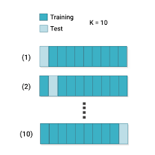

Training set is split into 10 subsets

Each subset becomes a validation set with the concatenation of the remaining nine becomong the new training set

Blind classification is performed on each training set and prediction is made on each validation set

Prediction is teherefore made on ten validation subsets

MCE is computed for each validation set for a total of ten MCEs

We then compure average and standard deviation of the ten MCEs

## Test MCE

Prediction:

```r
prd <- factor(rep(cl, nrow(tst)), levels = levels(trn$survived))
```

Confusion matrix:

```r
cm <- table(tst$survived, prd); cm
```

```
##       prd
##        Dead Surv
##   Dead   24    0
##   Surv   16    0
```

Test miss classification error (MCE):

```r
mce <-   1 - sum(diag(cm))/sum(cm); mce
```

```
## [1] 0.4
```

## Basic Tree

```r
fm0 <- rpart(survived ~ . , data = trn, method = 'class',
        parms = list(split = 'gini'),
        control = rpart.control(maxdepth = 1, xval = 10))
```

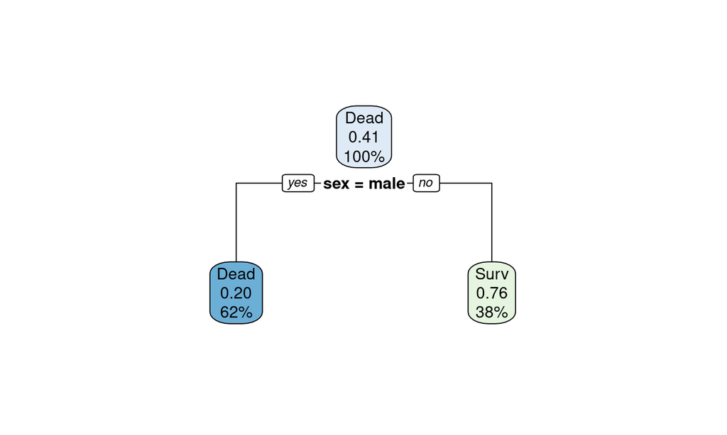

```r
rpart.plot(fm0)
```

## Root node

Root node holds 100% of data (passengers)

```r
n_survived <- sum(trn$survived == 'Surv')
n <- length(trn$survived)
```

A proportion of 0.413 passengers survived

```r
n_survived; n
```

```
## [1] 236
```

```
## [1] 571
```

```r
e0 <- n_survived/n
e0
```

```
## [1] 0.41331
```

Root node is classified as `Dead` node as the prevalent class is `Dead`

## Root node

As root node is classified as a `Dead` node.

Without any further split the miss classification error would be: 0.41331

Given that we are using variable `sex` as a splitting value, the split tells us that females survived and males died

```r
conf1 <- trn  |>
    group_by(survived, sex)  |>
    count()
  conf1
```

```
## # A tibble: 4 × 3
## # Groups:   survived, sex [4]
##   survived sex        n
##   <fct>    <chr>  <int>
## 1 Dead     female    53
## 2 Dead     male     282
## 3 Surv     female   164
## 4 Surv     male      72
```

Dead female and survived males become miss classifications

## Miss classification

The miss classification error becomes:

```r
dead_female <- conf1  |>
  filter (survived == 'Dead' & sex == 'female')  |>
  pull(n)
surv_male <- conf1  |>
  filter ( survived == 'Surv' & sex == 'male')  |>
  pull(n)
e1 <- (dead_female + surv_male)/n
e1
```

```
## [1] 0.2189142
```

Miss classification error at split one as proportion of Miss classification error at split zero becomes:

```r
e <- e1/e0
e
```

```
## [1] 0.529661
```

## print cp

Function `printcp()` makes all of this for us

```r
printcp(fm0)
```

```
##
## Classification tree:
## rpart(formula = survived ~ ., data = trn, method = "class", parms = list(split = "gini"),
##     control = rpart.control(maxdepth = 1, xval = 10))
##
## Variables actually used in tree construction:
## [1] sex
##
## Root node error: 236/571 = 0.41331
##
## n= 571
##
##        CP nsplit rel error  xerror     xstd
## 1 0.47034      0   1.00000 1.00000 0.049860
## 2 0.01000      1   0.52966 0.52966 0.041869
```

## Cross validation (xval)

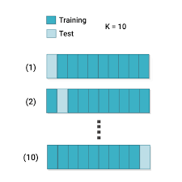

For each split

Training set is split into 10 subset

Tree is fit on nine out of ten subsets while wth 10<sub>th</sub> subset is used for prediction

Prediction is made on ten test subsets

MCE is computed for each test

## xval explained

```r
xval <- function(i , trn){
  val_i <- sample_frac(trn, .1)
  trn_i <- trn  |> suppressMessages(anti_join(val_i))
  fm_i <-  rpart(survived ~ . ,data = trn_i, method = 'class',
                parms = list(split = 'gini'),
                control = rpart.control(maxdepth = 1, xval = 10))
  prd_i <- predict(fm_i, newdata = val_i, type = "class")
  conf_mat_i <- table(val_i$survived, prd_i)
  err_i <- 1-sum(diag(conf_mat_i))/sum(conf_mat_i)
}
err <- purrr::map_dbl(1:10, xval, trn = trn)
```

```r
xerror <- mean(err); xerror
```

```
## [1] 0.2087719
```

```r
xstd <- sd(err); xstd
```

```
## [1] 0.0448809
```

## Cp

## Fit tree

```r
fm1 <- rpart(survived ~ . , data = trn, method = 'class',
        parms = list(split = 'gini'),
        control = rpart.control(cp = 0.00000001), xval = 10)
printcp(fm1)
```

```
##
## Classification tree:
## rpart(formula = survived ~ ., data = trn, method = "class", parms = list(split = "gini"),
##     control = rpart.control(cp = 1e-08), xval = 10)
##
## Variables actually used in tree construction:
## [1] age   class sex
##
## Root node error: 236/571 = 0.41331
##
## n= 571
##
##           CP nsplit rel error  xerror     xstd
## 1 0.47033898      0   1.00000 1.00000 0.049860
## 2 0.01694915      1   0.52966 0.52966 0.041869
## 3 0.01271186      3   0.49576 0.56356 0.042799
## 4 0.01059322      8   0.43220 0.53814 0.042108
## 5 0.00847458     10   0.41102 0.53814 0.042108
## 6 0.00635593     11   0.40254 0.50847 0.041252
## 7 0.00564972     15   0.37712 0.50424 0.041126
## 8 0.00000001     18   0.36017 0.48729 0.040607
```

## Plot full tree

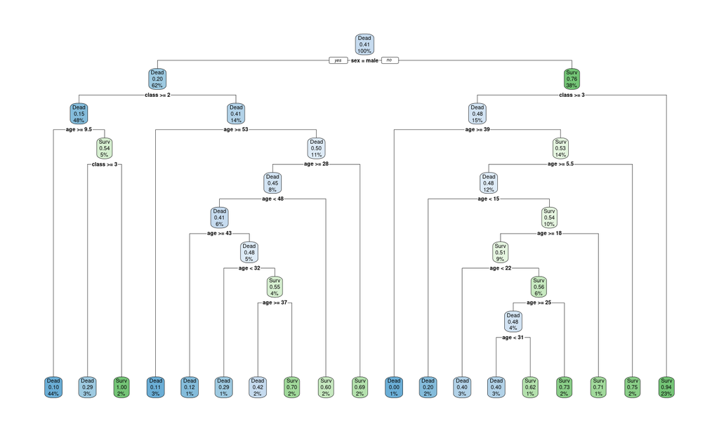

```r
rpart.plot(fm1)
```

## Cp table

```r
cptable1 <- fm1$cptable  |>
    as_tibble()  |>
    rename(rel_error = `rel error`)
cptable1
```

```
## # A tibble: 8 × 5
##           CP nsplit rel_error xerror   xstd
##        <dbl>  <dbl>     <dbl>  <dbl>  <dbl>
## 1 0.470           0     1      1     0.0499
## 2 0.0169          1     0.530  0.530 0.0419
## 3 0.0127          3     0.496  0.564 0.0428
## 4 0.0106          8     0.432  0.538 0.0421
## 5 0.00847        10     0.411  0.538 0.0421
## 6 0.00636        11     0.403  0.508 0.0413
## 7 0.00565        15     0.377  0.504 0.0411
## 8 0.00000001     18     0.360  0.487 0.0406
```

## Cp Plot

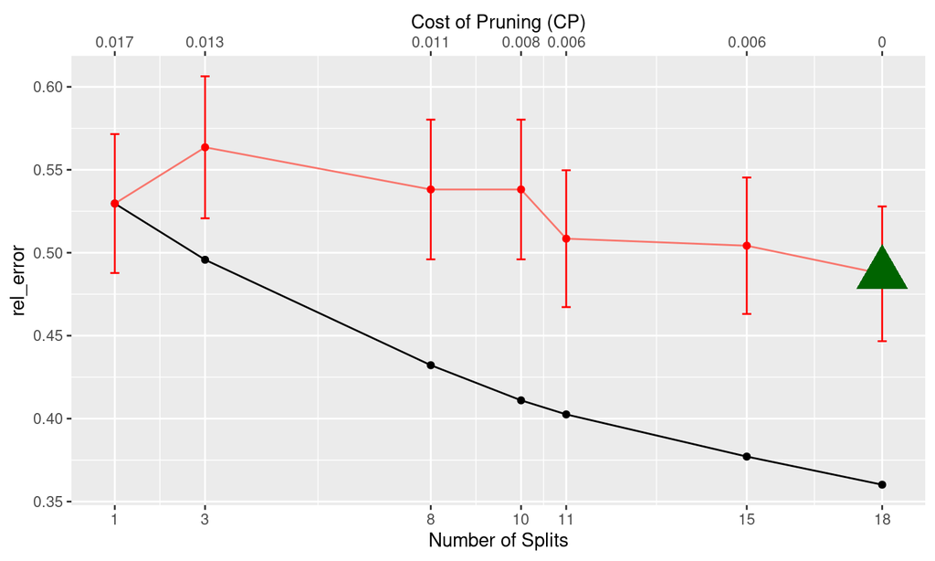

```r
bs_data <- cptable1  |>
    filter(xerror == min(xerror))  |>
    head(1)  |>
    mutate(h = xerror+xstd)


cptable_plot <- cptable1  |>
  filter ( rel_error < 1)

pl <- ggplot(cptable_plot) +
  geom_point(aes(nsplit,rel_error)) +
  geom_line(aes(nsplit, rel_error)) +
  geom_line(aes(nsplit, xerror, color = 'red')) +
  geom_errorbar(aes(x = nsplit,
                   ymin=xerror-xstd,
                   ymax=xerror+xstd),
                   width=.2,
                   color = 'red') +
geom_point(aes(nsplit, xerror), color = 'red') +
  geom_point(aes(nsplit, xerror),
  color = 'darkgreen',
            data = bs_data,
            size = 10,
            shape = 17) +
scale_x_continuous(name ="Number of Splits",breaks=cptable_plot$nsplit,
                  sec.axis = sec_axis( trans=~., name="Cost of Pruning (CP)", breaks=cptable_plot$nsplit,
                  labels = round(cptable_plot$CP,3))) +
                  theme(legend.position = "none")
print (pl)
```

## Best Cp

```r
best_cp <- cptable1  |>
mutate( lcl = min(xerror) - xstd,
        ucl = min(xerror) + xstd)  |>
      filter (xerror >= lcl, xerror <= ucl)  |>
      filter ( nsplit == min(nsplit)) |>
      pull(CP)
best_cp
```

```
## [1] 0.006355932
```

## Prune

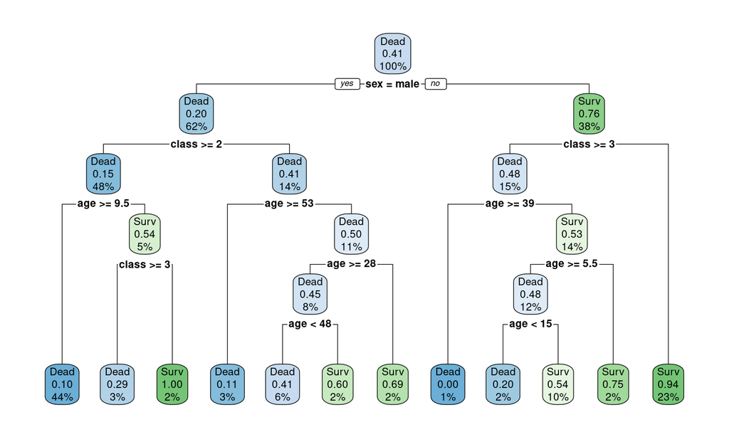

```r
fm2 <- prune(fm1, cp = best_cp)
rpart.plot(fm2)
```

## Summary

```r
summary(fm2)
```

```
## Call:
## rpart(formula = survived ~ ., data = trn, method = "class", parms = list(split = "gini"),
##     control = rpart.control(cp = 1e-08), xval = 10)
##   n= 571
##
##            CP nsplit rel error    xerror       xstd
## 1 0.470338983      0 1.0000000 1.0000000 0.04985955
## 2 0.016949153      1 0.5296610 0.5296610 0.04186898
## 3 0.012711864      3 0.4957627 0.5635593 0.04279892
## 4 0.010593220      8 0.4322034 0.5381356 0.04210787
## 5 0.008474576     10 0.4110169 0.5381356 0.04210787
## 6 0.006355932     11 0.4025424 0.5084746 0.04125236
##
## Variable importance
##   sex class   age
##    55    24    21
##
## Node number 1: 571 observations,    complexity param=0.470339
##   predicted class=Dead  expected loss=0.41331  P(node) =1
##     class counts:   335   236
##    probabilities: 0.587 0.413
##   left son=2 (354 obs) right son=3 (217 obs)
##   Primary splits:
##       sex   splits as  RL,        improve=82.095220, (0 missing)
##       class < 2.5   to the right, improve=33.525440, (0 missing)
##       age   < 8.5   to the right, improve= 6.340786, (0 missing)
##   Surrogate splits:
##       age < 15.5  to the right, agree=0.625, adj=0.014, (0 split)
##
## Node number 2: 354 observations,    complexity param=0.01271186
##   predicted class=Dead  expected loss=0.2033898  P(node) =0.619965
##     class counts:   282    72
##    probabilities: 0.797 0.203
##   left son=4 (275 obs) right son=5 (79 obs)
##   Primary splits:
##       class < 1.5   to the right, improve=8.272279, (0 missing)
##       age   < 9.5   to the right, improve=7.250091, (0 missing)
##   Surrogate splits:
##       age < 43.5  to the left,  agree=0.811, adj=0.152, (0 split)
##
```

[output cut: 123 more lines]

```
##
## Node number 45: 10 observations
##   predicted class=Surv  expected loss=0.4  P(node) =0.01751313
##     class counts:     4     6
##    probabilities: 0.400 0.600
##
## Node number 52: 10 observations
##   predicted class=Dead  expected loss=0.2  P(node) =0.01751313
##     class counts:     8     2
##    probabilities: 0.800 0.200
##
## Node number 53: 56 observations
##   predicted class=Surv  expected loss=0.4642857  P(node) =0.09807356
##     class counts:    26    30
##    probabilities: 0.464 0.536
```

## Variabel importance

## ref

https://stats.stackexchange.com/questions/117908/rpart-complexity-parameter-confusion

I have a purely categorical dataframe from the UCI machine learning database

https://archive.ics.uci.edu/ml/datasets/Diabetes+130-US+hospitals+for+years+1999-2008